# Pull in packages and saved versions of models

I pull in the saved versions of the models so I don't have to re-calculate them.

```r
setwd("~/Downloads")
library(AppliedPredictiveModeling)
library(caret)
library(gbm)
model_rf <- readRDS("model_rf.rds")
model_gbm <- readRDS("model_gbm.rds")
model_pca <- readRDS("model_pca.rds")
model_stack <- readRDS("model_stack.rds")
```

# Read in the data

I read in the full data set and the 20 case examples.

```r
data = read.csv("~/Downloads/pml-training.csv")
test_20 = read.csv("~/Downloads/pml-testing.csv")
```

# Divide the full data set into a training and test set

I first separate the full data set into a training and a test set. I use an 80%/20% split. I do this step before examining the data to ensure that I am not changing the analyses based on the characteristics of the test data.

```r
set.seed(2021)
trainIn<-createDataPartition(data$classe, p = 4/5)[[1]]
training<-data[trainIn,]
testing<-data[-trainIn,]
```

# Examine data

I first examine the data to get a better understanding of the structure and the variables in the data. One important issue I notice is that there is a high proportion of observations with missing data for many of the variables. It appears that these variables are missing for all the observations for which new window is equal to no. As such, it is possible that the values for these variables when new window is equal to 'no' are the same as the values for the all subsequent observations of that window. However, given that this information is not explicitly stated in the description of the data, I decided to take the data is given and proceed as if the data is truly missing.

```r
summary(training)
str(training)
```

# Examine missing data

I use a loop to identify whether the value is missing. For numeric/integer variables the missing values appear as NA and can be identified using the is.na function. For factor variables the missing values are listed as "" and can be identified by seeing whether the value equals "".

```r
missing<- matrix(NA, nrow = length(training$classe), ncol = length(colnames(training)))

for (i in 1:length(training$classe)) {
  for (j in 1:length(colnames(training))) {
    if (is.na(training[i,j]) | training[i,j]=="") {
      missing[i,j]<-TRUE} else
      {missing[i,j]<-FALSE}
  }
}
```

I use the missing data matrix to identify the proportion of each variable that are missing. I then only retain variables that have less than 50% missing. I could have potentially used imputation to retain the variables with missing values. However, the percentage missing was greater than 97% and with such a high percentage of missing values I did not feel comfortable using imputation. I create the subset of variables for both the training and the test sets. Importantly, I use the proportion missing created from the training set to identify the variables to retain for the test set. This has to do with ensuring that I keep the test set separate until doing the final predictions.

```r
prop_missing<-colMeans(missing)
training_alt<-training[,which(prop_missing<0.5)]
testing_alt<-testing[,which(prop_missing<0.5)]
test_20_alt<-test_20[,which(prop_missing<0.5)]
```

# Preprocessing

I standardized the numeric variables because I found that the variables had widely different values that they took. I first identify the numeric predictors, since you can only standardize numeric predictors. I also exclude variables that are numeric, but that I do not believe are relevant for prediction. Specifically, these are X, raw_timestamp_part_1, raw_timestamp_part_2, cvtd_timestamp, new_window, and num_window. I believe these variables are measuring aspects of when the observation took place and ID variables about the observation. These variables are important for understanding the data, but do not seem pertinent to use as predictors.

```r
numeric_pred<-sapply(training_alt, is.numeric)
numeric_pred[c(1,3,4,5,6,7)]<-FALSE
```

I use the preProcess function to center and scale the numeric variables. I first create the preProcess function using the training data. Then I apply it to the training data. I also apply the function created with the training data to the testing data because I did not want to use information about the test data to inform the model (this would be the case if I created the preprocessing function using the test data). After creating the data sets with the standardized variables, I merge the non-numeric and other variables back with the data.

```r
train_pre<-preProcess(training_alt[,numeric_pred],method=c("center","scale"))
training_preprocess<-predict(train_pre,training_alt[,numeric_pred])
training_final<-cbind(training_preprocess,training_alt[,c(1:7,60)])
testing_preprocess<-predict(train_pre,testing_alt[,numeric_pred])
testing_final<-cbind(testing_preprocess,testing_alt[,c(1:7,60)])
test_20_preprocess<-predict(train_pre,test_20_alt[,numeric_pred])
test_20_final<-cbind(test_20_preprocess,test_20_alt[,c(1:7,60)])
```

# Examine correlation

I examine the degree of correlation between the predictors in the training data. The degree of correlation may inform which modeling approaches may be more appropriate. I find that there are many predictors with correlation of 0.8 or greater. This finding suggests that I may want to incorporate principal components analysis to the high degree of correlation in the data.

```r
M<-abs(cor(training_final[,c(1:52)]))
diag(M)<-0
which(M>0.8,arr.ind=T)
```

```
##                  row col
## yaw_belt           3   1
## total_accel_belt   4   1
## accel_belt_y       9   1
## accel_belt_z      10   1
## accel_belt_x       8   2
## magnet_belt_x     11   2
## roll_belt          1   3
## roll_belt          1   4
## accel_belt_y       9   4
## accel_belt_z      10   4
## pitch_belt         2   8
## magnet_belt_x     11   8
## roll_belt          1   9
## total_accel_belt   4   9
## accel_belt_z      10   9
## roll_belt          1  10
## total_accel_belt   4  10
## accel_belt_y       9  10
## pitch_belt         2  11
## accel_belt_x       8  11
## gyros_arm_y       19  18
## gyros_arm_x       18  19
## magnet_arm_x      24  21
## accel_arm_x       21  24
## magnet_arm_z      26  25
## magnet_arm_y      25  26
## accel_dumbbell_x  34  28
## accel_dumbbell_z  36  29
## gyros_dumbbell_z  33  31
## gyros_forearm_z   46  31
## gyros_dumbbell_x  31  33
## gyros_forearm_z   46  33
## pitch_dumbbell    28  34
## yaw_dumbbell      29  36
## gyros_forearm_z   46  45
## gyros_dumbbell_x  31  46
## gyros_dumbbell_z  33  46
## gyros_forearm_y   45  46
```

# Models

I decided to run three different models and then use stacking to combine the predictors. The models are 1) random forest, 2) gradient boosting, and 3) multinomial logistic regression with principal components analysis. The first two models are often among the best performing in competitions and I use principal components analysis because of the high degree of correlation I observed earlier. For all three approaches I use K-fold cross-validation with ten folds. Ideally, I would have done repeated K-fold cross-validation, but given the size of the data and the time it takes to run the random forest and gradient boosting models, I decided that K-fold cross-validation with ten folds would be sufficient. Ten folds is a common choice for the number of folds because very high values of K are associated with more variance and very low numbers are associated with more bias. That is, ten folds tends to be judged as balancing the bias-variance tradeoff reasonably well. The value of doing K-fold cross-validation is that it helps to avoid overfitting when training the models.

```r
set.seed(2021)
model_rf<-train(classe~.,data=training_final[,c(1:52,54,60)],method="rf",trControl=trainControl(method="cv",number=10))
model_gbm<-train(classe~.,data=training_final[,c(1:52,54,60)],method="gbm",trControl=trainControl(method="cv",number=10))
model_pca<-train(classe~.,data=training_final[,c(1:52,54,60)],method="multinom",preProcess="pca",trControl=trainControl(method="cv",number=10))
```

The random forest model found that the optimal value for number of variables available for splitting was 29. The other values evaluated were 2 and 57 (all variables). We see that the performance was good for all three values, but it appears to decrease somewhat when using all variables, which may be a sign that overfitting is occurring when all variables are used. It may be possible to optimize the model further if I tried different values other than 2, 29, and 57. However, given that it appears 29 is working quite well, I don't believe this is necessary.

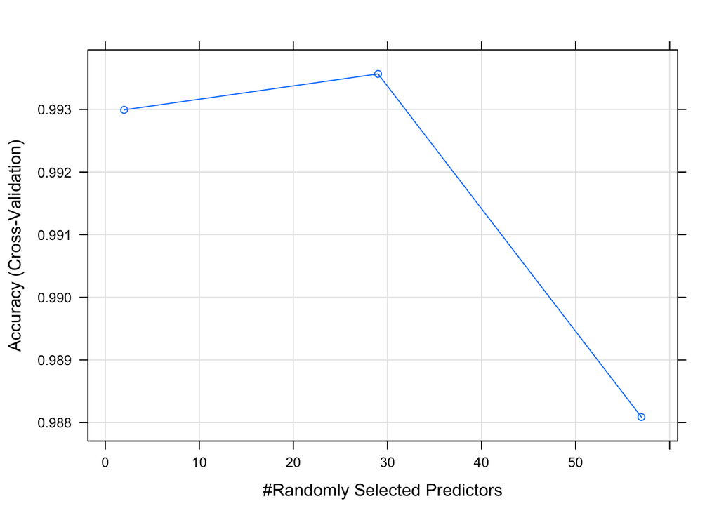

```r
plot(model_rf)
```

```r
model_rf
```

```
## Random Forest
##
## 15699 samples
##    53 predictor
##     5 classes: 'A', 'B', 'C', 'D', 'E'
##
## No pre-processing
## Resampling: Cross-Validated (10 fold)
## Summary of sample sizes: 14129, 14129, 14130, 14130, 14128, 14129, ...
## Resampling results across tuning parameters:
##
##   mtry  Accuracy   Kappa
##    2    0.9929930  0.9911359
##   29    0.9935668  0.9918617
##   57    0.9880882  0.9849304
##
## Accuracy was used to select the optimal model using the largest value.
## The final value used for the model was mtry = 29.
```

I also checked the gradient boosting and multinomial logistic/principal components analysis to see if the output is as expected. I don't show the output given the space considerations. The gradient boosting model appeared to perform reasonably well. However, it appeared that only 150 iterations were used. The best performance came with the 150th iteration and it may be possible to improve performance even more with more iterations. However, given that the performance was already quite strong, I did not feel this was necessary. For the multinomial logistic/principal components analysis there were 25 principal components identified.

```r
plot(model_gbm)
model_gbm
plot(model_pca)
model_pca
```

I calculate the predictions from each individual model on both the training data and the test data. The reason I predict for both is that I am interested in how well the predictions perform for the training data and how well they perform for the test data. If the predictions are very good for the training data and poor for the test data, then this may be a sign that I have overfit the training data.

```r
pred_train_rf<-predict(model_rf,data=training_final)
pred_train_gbm<-predict(model_gbm,data=training_final)
pred_train_pca<-predict(model_pca,data=training_final)

pred_test_rf<-predict(model_rf,newdata=testing_final)
pred_test_gbm<-predict(model_gbm,newdata=testing_final)
pred_test_pca<-predict(model_pca,newdata=testing_final)

pred_test_20_rf<-predict(model_rf,newdata=test_20_final)
pred_test_20_gbm<-predict(model_gbm,newdata=test_20_final)
pred_test_20_pca<-predict(model_pca,newdata=test_20_final)
```

I put together all the predictions into a data frame along with the outcome both for the training data and the testing data (I don't have the outcome for the 20 test examples).

```r
pred_train_DF<-data.frame(rf=pred_train_rf,gbm=pred_train_gbm,pca=pred_train_pca,classe=training$classe)
pred_test_DF<-data.frame(rf=pred_test_rf,gbm=pred_test_gbm,pca=pred_test_pca,classe=testing$classe)
pred_test_20_DF<-data.frame(rf=pred_test_20_rf,gbm=pred_test_20_gbm,pca=pred_test_20_pca,test_20_final$problem_id)
```

I train a stacked model using a random forest model with K-fold cross-validation. The predictors are the predicted outcome from the three original models. By stacking, I can hopefully take advantage of the strengths of each of the three approaches.

```r
set.seed(2021)
model_stack<-train(classe~.,method="rf",data=pred_train_DF,trControl=trainControl(method="cv",number=10))
```

```r
pred_train_stack<-predict(model_stack,data=pred_train_DF)
pred_test_stack<-predict(model_stack,newdata=pred_test_DF)
pred_test_20_stack<-predict(model_stack,newdata=pred_test_20_DF)
```

# Evaluating predictions

I first evaluate the model performance for the training data. The random forest and the stacked models both had perfect accuracy. The gradient boosting model was next with 0.9739 and the principal components analysis approach performed worst with an accuracy of only 0.5247. The results suggest that the performance is very good for all models except the multinomial logistic regression/principal components analysis model. However, getting perfect prediction makes me a bit concerned that I may be overfitting the data.

```r
confusionMatrix(pred_train_rf,training_final$classe)
```

```
## Confusion Matrix and Statistics
##
##           Reference
## Prediction    A    B    C    D    E
##          A 4464    0    0    0    0
##          B    0 3038    0    0    0
##          C    0    0 2738    0    0
##          D    0    0    0 2573    0
##          E    0    0    0    0 2886
##
## Overall Statistics
##
##                Accuracy : 1
##                  95% CI : (0.9998, 1)
##     No Information Rate : 0.2843
##     P-Value [Acc > NIR] : < 2.2e-16
##
##                   Kappa : 1
##
##  Mcnemar's Test P-Value : NA
##
## Statistics by Class:
##
##                      Class: A Class: B Class: C Class: D Class: E
## Sensitivity            1.0000   1.0000   1.0000   1.0000   1.0000
## Specificity            1.0000   1.0000   1.0000   1.0000   1.0000
## Pos Pred Value         1.0000   1.0000   1.0000   1.0000   1.0000
## Neg Pred Value         1.0000   1.0000   1.0000   1.0000   1.0000
## Prevalence             0.2843   0.1935   0.1744   0.1639   0.1838
## Detection Rate         0.2843   0.1935   0.1744   0.1639   0.1838
## Detection Prevalence   0.2843   0.1935   0.1744   0.1639   0.1838
## Balanced Accuracy      1.0000   1.0000   1.0000   1.0000   1.0000
```

```r
confusionMatrix(pred_train_gbm,training_final$classe)
```

```
## Confusion Matrix and Statistics
##
##           Reference
## Prediction    A    B    C    D    E
##          A 4419   64    0    2    6
##          B   35 2926   58    9   13
##          C    9   46 2646   74   14
##          D    0    2   27 2477   32
##          E    1    0    7   11 2821
##
## Overall Statistics
##
##                Accuracy : 0.9739
##                  95% CI : (0.9713, 0.9763)
##     No Information Rate : 0.2843
##     P-Value [Acc > NIR] : < 2.2e-16
##
##                   Kappa : 0.967
##
##  Mcnemar's Test P-Value : 2.578e-12
##
## Statistics by Class:
##
##                      Class: A Class: B Class: C Class: D Class: E
## Sensitivity            0.9899   0.9631   0.9664   0.9627   0.9775
## Specificity            0.9936   0.9909   0.9890   0.9954   0.9985
## Pos Pred Value         0.9840   0.9622   0.9487   0.9760   0.9933
## Neg Pred Value         0.9960   0.9912   0.9929   0.9927   0.9949
## Prevalence             0.2843   0.1935   0.1744   0.1639   0.1838
## Detection Rate         0.2815   0.1864   0.1685   0.1578   0.1797
## Detection Prevalence   0.2861   0.1937   0.1777   0.1617   0.1809
## Balanced Accuracy      0.9918   0.9770   0.9777   0.9790   0.9880
```

```r
confusionMatrix(pred_train_pca,training_final$classe)
```

```
## Confusion Matrix and Statistics
##
##           Reference
## Prediction    A    B    C    D    E
##          A 2944  700  792  258  303
##          B  412 1267  297  358  566
##          C  422  445 1352  345  349
##          D  575  315  193 1327  321
##          E  111  311  104  285 1347
##
## Overall Statistics
##
##                Accuracy : 0.5247
##                  95% CI : (0.5168, 0.5325)
##     No Information Rate : 0.2843
##     P-Value [Acc > NIR] : < 2.2e-16
##
##                   Kappa : 0.3965
##
##  Mcnemar's Test P-Value : < 2.2e-16
##
## Statistics by Class:
##
##                      Class: A Class: B Class: C Class: D Class: E
## Sensitivity            0.6595  0.41705  0.49379  0.51574   0.4667
## Specificity            0.8173  0.87102  0.87956  0.89304   0.9367
## Pos Pred Value         0.5892  0.43690  0.46413  0.48590   0.6242
## Neg Pred Value         0.8580  0.86163  0.89160  0.90392   0.8863
## Prevalence             0.2843  0.19352  0.17441  0.16390   0.1838
## Detection Rate         0.1875  0.08071  0.08612  0.08453   0.0858
## Detection Prevalence   0.3183  0.18473  0.18555  0.17396   0.1375
## Balanced Accuracy      0.7384  0.64404  0.68668  0.70439   0.7017
```

```r
confusionMatrix(pred_train_stack,training_final$classe)
```

```
## Confusion Matrix and Statistics
##
##           Reference
## Prediction    A    B    C    D    E
##          A 4464    0    0    0    0
##          B    0 3038    0    0    0
##          C    0    0 2738    0    0
##          D    0    0    0 2573    0
##          E    0    0    0    0 2886
##
## Overall Statistics
##
##                Accuracy : 1
##                  95% CI : (0.9998, 1)
##     No Information Rate : 0.2843
##     P-Value [Acc > NIR] : < 2.2e-16
##
##                   Kappa : 1
##
##  Mcnemar's Test P-Value : NA
##
## Statistics by Class:
##
##                      Class: A Class: B Class: C Class: D Class: E
## Sensitivity            1.0000   1.0000   1.0000   1.0000   1.0000
## Specificity            1.0000   1.0000   1.0000   1.0000   1.0000
## Pos Pred Value         1.0000   1.0000   1.0000   1.0000   1.0000
## Neg Pred Value         1.0000   1.0000   1.0000   1.0000   1.0000
## Prevalence             0.2843   0.1935   0.1744   0.1639   0.1838
## Detection Rate         0.2843   0.1935   0.1744   0.1639   0.1838
## Detection Prevalence   0.2843   0.1935   0.1744   0.1639   0.1838
## Balanced Accuracy      1.0000   1.0000   1.0000   1.0000   1.0000
```

```r
confusionMatrix(pred_test_rf,testing_final$classe)
```

```
## Confusion Matrix and Statistics
##
##           Reference
## Prediction    A    B    C    D    E
##          A 1113    5    0    0    0
##          B    2  753    0    6    0
##          C    0    1  683    5    0
##          D    0    0    1  632    2
##          E    1    0    0    0  719
##
## Overall Statistics
##
##                Accuracy : 0.9941
##                  95% CI : (0.9912, 0.9963)
##     No Information Rate : 0.2845
##     P-Value [Acc > NIR] : < 2.2e-16
##
##                   Kappa : 0.9926
##
##  Mcnemar's Test P-Value : NA
##
## Statistics by Class:
##
##                      Class: A Class: B Class: C Class: D Class: E
## Sensitivity            0.9973   0.9921   0.9985   0.9829   0.9972
## Specificity            0.9982   0.9975   0.9981   0.9991   0.9997
## Pos Pred Value         0.9955   0.9895   0.9913   0.9953   0.9986
## Neg Pred Value         0.9989   0.9981   0.9997   0.9967   0.9994
## Prevalence             0.2845   0.1935   0.1744   0.1639   0.1838
## Detection Rate         0.2837   0.1919   0.1741   0.1611   0.1833
## Detection Prevalence   0.2850   0.1940   0.1756   0.1619   0.1835
## Balanced Accuracy      0.9978   0.9948   0.9983   0.9910   0.9985
```

```r
confusionMatrix(pred_test_gbm,testing_final$classe)
```

```
## Confusion Matrix and Statistics
##
##           Reference
## Prediction    A    B    C    D    E
##          A 1100   29    0    1    0
##          B   11  714   27    4    6
##          C    4   16  651   27    9
##          D    0    0    6  607    9
##          E    1    0    0    4  697
##
## Overall Statistics
##
##                Accuracy : 0.9607
##                  95% CI : (0.9542, 0.9666)
##     No Information Rate : 0.2845
##     P-Value [Acc > NIR] : < 2.2e-16
##
##                   Kappa : 0.9503
##
##  Mcnemar's Test P-Value : 1.604e-07
##
## Statistics by Class:
##
##                      Class: A Class: B Class: C Class: D Class: E
## Sensitivity            0.9857   0.9407   0.9518   0.9440   0.9667
## Specificity            0.9893   0.9848   0.9827   0.9954   0.9984
## Pos Pred Value         0.9735   0.9370   0.9208   0.9759   0.9929
## Neg Pred Value         0.9943   0.9858   0.9897   0.9891   0.9925
## Prevalence             0.2845   0.1935   0.1744   0.1639   0.1838
## Detection Rate         0.2804   0.1820   0.1659   0.1547   0.1777
## Detection Prevalence   0.2880   0.1942   0.1802   0.1586   0.1789
## Balanced Accuracy      0.9875   0.9628   0.9672   0.9697   0.9826
```

```r
confusionMatrix(pred_test_pca,testing_final$classe)
```

```
## Confusion Matrix and Statistics
##
##           Reference
## Prediction   A   B   C   D   E
##          A 738 179 201  55  80
##          B 108 329  81 114 145
##          C  93 100 331  90  81
##          D 151  77  43 317  93
##          E  26  74  28  67 322
##
## Overall Statistics
##
##                Accuracy : 0.5192
##                  95% CI : (0.5035, 0.535)
##     No Information Rate : 0.2845
##     P-Value [Acc > NIR] : < 2.2e-16
##
##                   Kappa : 0.3893
##
##  Mcnemar's Test P-Value : < 2.2e-16
##
## Statistics by Class:
##
##                      Class: A Class: B Class: C Class: D Class: E
## Sensitivity            0.6613  0.43347  0.48392  0.49300  0.44660
## Specificity            0.8165  0.85841  0.88762  0.88902  0.93910
## Pos Pred Value         0.5890  0.42342  0.47626  0.46549  0.62282
## Neg Pred Value         0.8584  0.86332  0.89064  0.89944  0.88285
## Prevalence             0.2845  0.19347  0.17436  0.16391  0.18379
## Detection Rate         0.1881  0.08386  0.08437  0.08081  0.08208
## Detection Prevalence   0.3194  0.19806  0.17716  0.17359  0.13179
## Balanced Accuracy      0.7389  0.64594  0.68577  0.69101  0.69285
```

```r
confusionMatrix(pred_test_stack,testing_final$classe)
```

```
## Confusion Matrix and Statistics
##
##           Reference
## Prediction    A    B    C    D    E
##          A 1113    5    0    0    0
##          B    2  753    0    6    0
##          C    0    1  683    5    0
##          D    0    0    1  632    2
##          E    1    0    0    0  719
##
## Overall Statistics
##
##                Accuracy : 0.9941
##                  95% CI : (0.9912, 0.9963)
##     No Information Rate : 0.2845
##     P-Value [Acc > NIR] : < 2.2e-16
##
##                   Kappa : 0.9926
##
##  Mcnemar's Test P-Value : NA
##
## Statistics by Class:
##
##                      Class: A Class: B Class: C Class: D Class: E
## Sensitivity            0.9973   0.9921   0.9985   0.9829   0.9972
## Specificity            0.9982   0.9975   0.9981   0.9991   0.9997
## Pos Pred Value         0.9955   0.9895   0.9913   0.9953   0.9986
## Neg Pred Value         0.9989   0.9981   0.9997   0.9967   0.9994
## Prevalence             0.2845   0.1935   0.1744   0.1639   0.1838
## Detection Rate         0.2837   0.1919   0.1741   0.1611   0.1833
## Detection Prevalence   0.2850   0.1940   0.1756   0.1619   0.1835
## Balanced Accuracy      0.9978   0.9948   0.9983   0.9910   0.9985
```

I predict the results for the 20 test examples using the stacked model. I base this decision on the performance in the training data, which was equally good for both the random forest and the stacked model. I did not base this decision on how it performed on the test data above because that would mean I was using the test data to guide the modeling.

```r
print(pred_test_20_stack)
```

```
##  [1] B A B A A E D B A A B C B A E E A B B B
## Levels: A B C D E
```